# Planar data classification with one hidden layer

Welcome to your week 3 programming assignment. It's time to build your first neural network, which will have a hidden layer. You will see a big difference between this model and the one you implemented using logistic regression.

**You will learn how to:**

- Implement a 2-class classification neural network with a single hidden layer
- Use units with a non-linear activation function, such as tanh
- Compute the cross entropy loss
- Implement forward and backward propagation

## 1 - Packages

Let's first import all the packages that you will need during this assignment.

- numpy is the fundamental package for scientific computing with Python.
- [sklearn](http://scikit-learn.org/stable/) provides simple and efficient tools for data mining and data analysis.
- [matplotlib](http://matplotlib.org) is a library for plotting graphs in Python.
- testCases provides some test examples to assess the correctness of your functions
- planar_utils provide various useful functions used in this assignment

```python
# Package imports
import numpy as np
import matplotlib.pyplot as plt
from testCases import *
import sklearn
import sklearn.datasets
import sklearn.linear_model
import torch
from planar_utils import plot_decision_boundary, sigmoid, load_planar_dataset, load_extra_datasets

%matplotlib inline

np.random.seed(1) # set a seed so that the results are consistent
torch.set_printoptions(precision=8)
```

## 2 - Dataset

First, let's get the dataset you will work on. The following code will load a "flower" 2-class dataset into variables `X` and `Y`.

```python
X, Y = load_planar_dataset()
```

Visualize the dataset using matplotlib. The data looks like a "flower" with some red (label y=0) and some blue (y=1) points. Your goal is to build a model to fit this data.

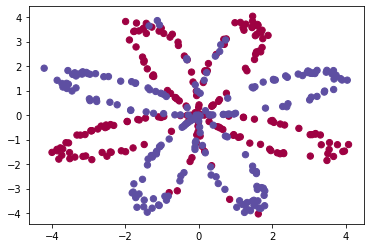

```python
# Visualize the data:
plt.scatter(X[0, :], X[1, :], c=Y, s=40, cmap=plt.cm.Spectral);
```

You have:

```
- a numpy-array (matrix) X that contains your features (x1, x2)
- a numpy-array (vector) Y that contains your labels (red:0, blue:1).
```

Lets first get a better sense of what our data is like.

**Exercise**: How many training examples do you have? In addition, what is the `shape` of the variables `X` and `Y`?

**Hint**: How do you get the shape of a numpy array? [(help)](https://docs.scipy.org/doc/numpy/reference/generated/numpy.ndarray.shape.html)

```python
### START CODE HERE ### (≈ 3 lines of code)
shape_X = X.shape
shape_Y = Y.shape
m = len(Y[0, :])
### END CODE HERE ###

print ('The shape of X is: ' + str(shape_X))
print ('The shape of Y is: ' + str(shape_Y))
print ('I have m = %d training examples!' % (m))
```

```
The shape of X is: (2, 400)
The shape of Y is: (1, 400)
I have m = 400 training examples!
```

**Expected Output**:

| **shape of X** | (2, 400) |
| --- | --- |
| **shape of Y** | (1, 400) |
| **m** | 400 |

## 3 - Simple Logistic Regression

Before building a full neural network, lets first see how logistic regression performs on this problem. You can use sklearn's built-in functions to do that. Run the code below to train a logistic regression classifier on the dataset.

```python
# Train the logistic regression classifier
clf = sklearn.linear_model.LogisticRegressionCV();
clf.fit(X.T, Y.T);
```

You can now plot the decision boundary of these models. Run the code below.

```
Accuracy of logistic regression: 47 % (percentage of correctly labelled datapoints)
Accuracy using sklearn inbuilt logic: 47 %
```

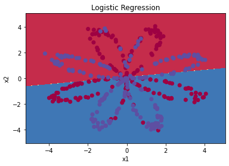

```python
# Plot the decision boundary for logistic regression
plot_decision_boundary(lambda x: clf.predict(x), X, Y)
plt.title("Logistic Regression")

# Print accuracy
LR_predictions = clf.predict(X.T)
# If y-pred is 1 and y-actual is also 1 then np.dot(Y, LR_predictions) gives the number of such      # correct predictions, similarly is y-pred is 0 and y-actual is also 0 then np.dot(1-Y,              # 1-LR_predictions) gives the number of such correct predictions
print ('Accuracy of logistic regression: %d ' % float((np.dot(Y, LR_predictions) + np.dot(1 - Y,1 - LR_predictions)) / float(Y.size) * 100) + '% ' + "(percentage of correctly labelled datapoints)")
# Another way to get the prediction accuracy score
print('Accuracy using sklearn inbuilt logic: %d ' % float(clf.score(X.T, Y.T) * 100) + '%')
```

**Expected Output**:

| **Accuracy** | 47% |
| --- | --- |

**Interpretation**: The dataset is not linearly separable, so logistic regression doesn't perform well. Hopefully a neural network will do better. Let's try this now!

```python
# Convert the input and output numpy arrays to equivalent tensors
X = torch.tensor(X, dtype=torch.float64)
Y = torch.tensor(Y, dtype=torch.float64)
```

## 4 - Neural Network model

Logistic regression did not work well on the "flower dataset". You are going to train a Neural Network with a single hidden layer.

**Here is our model**:

[figure not shown]

**Mathematically**:

For one example $x^{(i)}$: $$z^{[1] (i)} = W^{[1]} x^{(i)} + b^{[1] (i)}\tag{1}$$ $$a^{[1] (i)} = \tanh(z^{[1] (i)})\tag{2}$$ $$z^{[2] (i)} = W^{[2]} a^{[1] (i)} + b^{[2] (i)}\tag{3}$$ $$\hat{y}^{(i)} = a^{[2] (i)} = \sigma(z^{ [2] (i)})\tag{4}$$ $$y^{(i)}_{prediction} = \begin{cases} 1 & \mbox{if } a^{[2](i)} > 0.5 \\ 0 & \mbox{otherwise } \end{cases}\tag{5}$$

Given the predictions on all the examples, you can also compute the cost $J$ as follows: $$J = - \frac{1}{m} \sum\limits_{i = 0}^{m} \large\left(\small y^{(i)}\log\left(a^{[2] (i)}\right) + (1-y^{(i)})\log\left(1- a^{[2] (i)}\right) \large \right) \small \tag{6}$$

**Reminder**: The general methodology to build a Neural Network is to:

```
1. Define the neural network structure ( # of input units,  # of hidden units, etc).
2. Initialize the model's parameters
3. Loop:
    - Implement forward propagation
    - Compute loss
    - Implement backward propagation to get the gradients
    - Update parameters (gradient descent)
```

You often build helper functions to compute steps 1-3 and then merge them into one function we call `nn_model()`. Once you've built `nn_model()` and learnt the right parameters, you can make predictions on new data.

### 4.1 - Defining the neural network structure

**Exercise**: Define three variables:

```
- n_x: the size of the input layer
- n_h: the size of the hidden layer (set this to 4)
- n_y: the size of the output layer
```

**Hint**: Use shapes of X and Y to find n_x and n_y. Also, hard code the hidden layer size to be 4.

```python
# GRADED FUNCTION: layer_sizes

def layer_sizes(X, Y):
    """
    Arguments:
    X -- input dataset of shape (input size, number of examples)
    Y -- labels of shape (output size, number of examples)

    Returns:
    n_x -- the size of the input layer
    n_h -- the size of the hidden layer
    n_y -- the size of the output layer
    """
    ### START CODE HERE ### (≈ 3 lines of code)
    n_x = X.shape[0]
    n_h = 4
    n_y = Y.shape[0]
    ### END CODE HERE ###
    return (n_x, n_h, n_y)
```

```python
X_assess, Y_assess = layer_sizes_test_case()
(n_x, n_h, n_y) = layer_sizes(X_assess, Y_assess)
print("The size of the input layer is: n_x = " + str(n_x))
print("The size of the hidden layer is: n_h = " + str(n_h))
print("The size of the output layer is: n_y = " + str(n_y))
```

```
The size of the input layer is: n_x = 5
The size of the hidden layer is: n_h = 4
The size of the output layer is: n_y = 2
```

**Expected Output** (these are not the sizes you will use for your network, they are just used to assess the function you've just coded).

| **n_x** | 5 |
| --- | --- |
| **n_h** | 4 |
| **n_y** | 2 |

### 4.2 - Initialize the model's parameters

**Exercise**: Implement the function `initialize_parameters()`.

**Instructions**:

- Make sure your parameters' sizes are right. Refer to the neural network figure above if needed.
- You will initialize the weights matrices with random values.
  - Use: `np.random.randn(a,b) * 0.01` to randomly initialize a matrix of shape (a,b).
- You will initialize the bias vectors as zeros.
  - Use: `np.zeros((a,b))` to initialize a matrix of shape (a,b) with zeros.

```python
# GRADED FUNCTION: initialize_parameters

def initialize_parameters(n_x, n_h, n_y):
    """
    Argument:
    n_x -- size of the input layer
    n_h -- size of the hidden layer
    n_y -- size of the output layer

    Returns:
    params -- python dictionary containing your parameters:
                    W1 -- weight matrix of shape (n_h, n_x)
                    b1 -- bias vector of shape (n_h, 1)
                    W2 -- weight matrix of shape (n_y, n_h)
                    b2 -- bias vector of shape (n_y, 1)
    """

    np.random.seed(2) # we set up a seed so that your output matches ours although the initialization is random.

    W1 = torch.tensor((np.random.randn(n_h, n_x) * 0.01), requires_grad=True)
    b1 = torch.zeros((n_h, 1), requires_grad=True)
    W2 = torch.tensor((np.random.randn(n_y, n_h) * 0.01), requires_grad=True)
    b2 = torch.zeros((n_y, 1), requires_grad=True)

    assert (W1.shape == (n_h, n_x))
    assert (b1.shape == (n_h, 1))
    assert (W2.shape == (n_y, n_h))
    assert (b2.shape == (n_y, 1))

    parameters = {"W1": W1,
                  "b1": b1,
                  "W2": W2,
                  "b2": b2}

    return parameters
```

```python
n_x, n_h, n_y = initialize_parameters_test_case()

parameters = initialize_parameters(n_x, n_h, n_y)
print("W1 = " + str(parameters["W1"]))
print("b1 = " + str(parameters["b1"]))
print("W2 = " + str(parameters["W2"]))
print("b2 = " + str(parameters["b2"]))
```

```
W1 = tensor([[-0.00416758, -0.00056267],
        [-0.02136196,  0.01640271],
        [-0.01793436, -0.00841747],
        [ 0.00502881, -0.01245288]], dtype=torch.float64, requires_grad=True)
b1 = tensor([[0.],
        [0.],
        [0.],
        [0.]], requires_grad=True)
W2 = tensor([[-0.01057952, -0.00909008,  0.00551454,  0.02292208]],
       dtype=torch.float64, requires_grad=True)
b2 = tensor([[0.]], requires_grad=True)
```

**Expected Output**:

| **W1** | [[-0.00416758 -0.00056267] [-0.02136196 0.01640271] [-0.01793436 -0.00841747] [ 0.00502881 -0.01245288]] |
| --- | --- |
| **b1** | [[ 0.] [ 0.] [ 0.] [ 0.]] |
| **W2** | [[-0.01057952 -0.00909008 0.00551454 0.02292208]] |
| **b2** | [[ 0.]] |

### 4.3 - The Loop

**Question**: Implement `forward_propagation()`.

**Instructions**:

- Look above at the mathematical representation of your classifier.
- You can use the function `sigmoid()`. It is built-in (imported) in the notebook.
- You can use the function `np.tanh()`. It is part of the numpy library.
- The steps you have to implement are:
  1. Retrieve each parameter from the dictionary "parameters" (which is the output of `initialize_parameters()`) by using `parameters[".."]`.
  2. Implement Forward Propagation. Compute $Z^{[1]}, A^{[1]}, Z^{[2]}$ and $A^{[2]}$ (the vector of all your predictions on all the examples in the training set).
- Values needed in the backpropagation are stored in "`cache`". The `cache` will be given as an input to the backpropagation function.

```python
# GRADED FUNCTION: forward_propagation
def check_and_convert(input_arr):
    if isinstance(input_arr, np.ndarray):
        input_arr = torch.tensor(input_arr)
    return input_arr

def forward_propagation(X, parameters):
    """
    Argument:
    X -- input data of size (n_x, m)
    parameters -- python dictionary containing your parameters (output of initialization function)

    Returns:
    A2 -- The sigmoid output of the second activation
    cache -- a dictionary containing "Z1", "A1", "Z2" and "A2"
    """
    # Retrieve each parameter from the dictionary "parameters"
    X = check_and_convert(X)
    ### START CODE HERE ### (≈ 4 lines of code)
    W1 = parameters.get("W1")
    W1 = check_and_convert(W1)
    b1 = parameters.get("b1")
    b1 = check_and_convert(b1)
    W2 = parameters.get("W2")
    W2 = check_and_convert(W2)
    b2 = parameters.get("b2")
    b2 = check_and_convert(b2)
    ### END CODE HERE ###

    # Implement Forward Propagation to calculate A2 (probabilities)
    ### START CODE HERE ### (≈ 4 lines of code)
    Z1 = torch.matmul(W1, X) + b1
    A1 = torch.tanh(Z1)
    Z2 = torch.matmul(W2, A1) + b2
    A2 = torch.sigmoid(Z2)
    ### END CODE HERE ###

    assert(A2.shape == (1, X.shape[1]))

    cache = {"Z1": Z1,
             "A1": A1,
             "Z2": Z2,
             "A2": A2}

    return A2, cache
```

```python
X_assess, parameters = forward_propagation_test_case_pytorch()
A2, cache = forward_propagation(X_assess, parameters)

# Note: we use the mean here just to make sure that your output matches ours.
print(torch.mean(cache['Z1']), torch.mean(cache['A1']), torch.mean(cache['Z2']), torch.mean(cache['A2']))
```

```
tensor(-0.00049976, dtype=torch.float64, grad_fn=<MeanBackward0>) tensor(-0.00049696, dtype=torch.float64, grad_fn=<MeanBackward0>) tensor(0.00043819, dtype=torch.float64, grad_fn=<MeanBackward0>) tensor(0.50010955, dtype=torch.float64, grad_fn=<MeanBackward0>)
```

**Expected Output**:

| -0.000499755777742 -0.000496963353232 0.000438187450959 0.500109546852 |
| --- |

Now that you have computed $A^{[2]}$ (in the Python variable "`A2`"), which contains $a^{[2](i)}$ for every example, you can compute the cost function as follows:

$$J = - \frac{1}{m} \sum\limits_{i = 0}^{m} \large{(} \small y^{(i)}\log\left(a^{[2] (i)}\right) + (1-y^{(i)})\log\left(1- a^{[2] (i)}\right) \large{)} \small\tag{13}$$

**Exercise**: Implement `compute_cost()` to compute the value of the cost $J$.

**Instructions**:

- There are many ways to implement the cross-entropy loss. To help you, we give you how we would have implemented $- \sum\limits_{i=0}^{m} y^{(i)}\log(a^{[2](i)})$:

  ```
  logprobs = np.multiply(np.log(A2),Y)
  cost = - np.sum(logprobs)                # no need to use a for loop!
  ```

(you can use either `np.multiply()` and then `np.sum()` or directly `np.dot()`).

```python
# GRADED FUNCTION: compute_cost

def compute_cost(A2, Y):
    """
    Computes the cross-entropy cost given in equation (13)

    Arguments:
    A2 -- The sigmoid output of the second activation, of shape (1, number of examples)
    Y -- "true" labels vector of shape (1, number of examples)

    Returns:
    cost -- cross-entropy cost given equation (13)
    """

    m = Y.shape[1] # number of example

    # Compute the cross-entropy cost
    ### START CODE HERE ### (≈ 2 lines of code)
    cost1 = torch.matmul(Y, torch.transpose(torch.log(A2), 0, 1))
    cost2 = torch.matmul(1-Y, torch.transpose(torch.log(1-A2), 0, 1))
    cost = (cost1 + cost2) * (-1/m)
    ### END CODE HERE ###
    return cost
```

### 4.4 - Integrate parts 4.1, 4.2 and 4.3 in nn_model()

**Question**: Build your neural network model in `nn_model()`.

**Instructions**: The neural network model has to use the previous functions in the right order.

```python
# GRADED FUNCTION: nn_model
import copy
import math

def zero_the_gradient(parameters):
    for key in parameters.keys():
        value = parameters[key]
        #print(f"key = {key} " + "value = " + str(value) + "grad = " + str(value.grad))
        if value.grad is not None:
            #print(f"Setting the gradient for {key} to zero")
            value.grad.zero_()


def nn_model(X, Y, n_h, num_iterations=10000, print_cost=False):
    """
    Arguments:
    X -- dataset of shape (2, number of examples)
    Y -- labels of shape (1, number of examples)
    n_h -- size of the hidden layer
    num_iterations -- Number of iterations in gradient descent loop
    print_cost -- if True, print the cost every 1000 iterations

    Returns:
    parameters -- parameters learnt by the model. They can then be used to predict.
    """

    np.random.seed(3)
    n_x = layer_sizes(X, Y)[0]
    n_y = layer_sizes(X, Y)[2]
    learning_rate = 1.2
    params = initialize_parameters(n_x, n_h, n_y)
    cost_arr = []

    # Loop (gradient descent)
    for i in range(0, num_iterations):
        # We need to set the gradient back to zero explicitly to prevent accumulation of gradients
        zero_the_gradient(params)
        A2, cache = forward_propagation(X, params)
        cost = compute_cost(A2, Y)
        cost_arr.append(cost)
        cost.backward()

        with torch.no_grad():
            W1 = params["W1"]
            dW1 = W1.grad
            W1 -= learning_rate * dW1
            b1 = params["b1"]
            db1 = b1.grad
            b1 -= learning_rate * db1
            W2 = params["W2"]
            dW2 = W2.grad
            W2 -= learning_rate * dW2
            b2 = params["b2"]
            db2 = b2.grad
            b2 -= learning_rate * db2

        if i % 1000 == 0:
            print ("Cost after iteration %i: %f" % (i, cost))

    return params, cost_arr
```

```
Cost after iteration 0: 0.692584
Cost after iteration 1000: nan
Cost after iteration 2000: nan
Cost after iteration 3000: nan
Cost after iteration 4000: nan
Cost after iteration 5000: nan
Cost after iteration 6000: nan
Cost after iteration 7000: nan
Cost after iteration 8000: nan
Cost after iteration 9000: nan
```

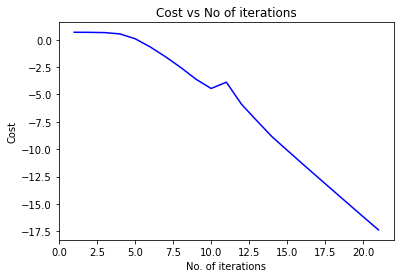

```
W1 = tensor([[nan, nan],
        [nan, nan],
        [nan, nan],
        [nan, nan]], dtype=torch.float64, requires_grad=True)
b1 = tensor([[nan],
        [nan],
        [nan],
        [nan]], requires_grad=True)
W2 = tensor([[nan, nan, nan, nan]], dtype=torch.float64, requires_grad=True)
b2 = tensor([[nan]], requires_grad=True)
```

```python
import matplotlib.pyplot as plt
import pandas as pd

X_assess, Y_assess = nn_model_test_case_pytorch()

parameters, cost_arr = nn_model(X_assess, Y_assess, 4, num_iterations=10000, print_cost=True)

def plot_cost_vs_iter(cost_arr, num_iter):
    iter_arr = np.arange(1, num_iter+1).reshape(num_iter, 1)
    fig, ax_costiter = plt.subplots()
    ax_costiter.set_xlabel('No. of iterations')
    ax_costiter.set_ylabel('Cost')
    ax_costiter.plot(iter_arr, cost_arr, color='blue')
    plt.title('Cost vs No of iterations')
    plt.show()

plot_cost_vs_iter(cost_arr, 10000)
print("W1 = " + str(parameters["W1"]))
print("b1 = " + str(parameters["b1"]))
print("W2 = " + str(parameters["W2"]))
print("b2 = " + str(parameters["b2"]))
```

**Expected Output**:

[output not shown]

### 4.5 Predictions

**Question**: Use your model to predict by building predict(). Use forward propagation to predict results.

**Reminder**: predictions = $y_{prediction} = \mathbb 1 \text{{activation > 0.5}} = \begin{cases} 1 & \text{if}\ activation > 0.5 \\ 0 & \text{otherwise} \end{cases}$

As an example, if you would like to set the entries of a matrix X to 0 and 1 based on a threshold you would do: `X_new = (X > threshold)`

```python
# GRADED FUNCTION: predict

def predict(parameters, X):
    """
    Using the learned parameters, predicts a class for each example in X

    Arguments:
    parameters -- python dictionary containing your parameters
    X -- input data of size (n_x, m)

    Returns
    predictions -- vector of predictions of our model (red: 0 / blue: 1)
    """

    # Computes probabilities using forward propagation, and classifies to 0/1
    # using 0.5 as the threshold.
    ### START CODE HERE ### (≈ 2 lines of code)
    A2, cache = forward_propagation(X, parameters)
    predictions = torch.round(A2)
    ### END CODE HERE ###

    return predictions
```

It is time to run the model and see how it performs on a planar dataset. Run the following code to test your model with a single hidden layer of $n_h$ hidden units.

```
Cost after iteration 0: 0.693048
Cost after iteration 1000: 0.288083
Cost after iteration 2000: 0.254385
Cost after iteration 3000: 0.233864
Cost after iteration 4000: 0.226792
Cost after iteration 5000: 0.222644
Cost after iteration 6000: 0.219731
Cost after iteration 7000: 0.217504
Cost after iteration 8000: 0.218843
Cost after iteration 9000: 0.218387
```

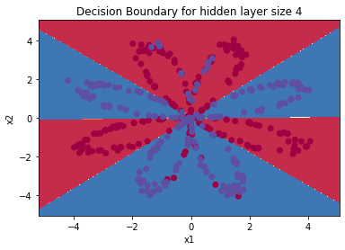

```python
# Build a model with a n_h-dimensional hidden layer
parameters, cost_arr = nn_model(X, Y, n_h = 4, num_iterations=10000, print_cost=True)

# Plot the decision boundary
plot_decision_boundary(lambda x: predict(parameters, x.T), X, Y)
plt.title("Decision Boundary for hidden layer size " + str(4))
```

**Expected Output**:

| **Cost after iteration 9000** | 0.218607 |
| --- | --- |

```python
# Print accuracy
predictions_tensor = predict(parameters, X)
# convert the predictions tensor to numpy array
predictions = predictions_tensor.cpu().detach().numpy()
accuracy = float((np.dot(Y, predictions.T) + np.dot(1 - Y, 1 - predictions.T)) * 100 / Y.size()[1])
print(f'Accuracy: {accuracy}%')
```

```
Accuracy: 90.75%
```

**Expected Output**:

| **Accuracy** | 90% |
| --- | --- |

Accuracy is really high compared to Logistic Regression. The model has learnt the leaf patterns of the flower! Neural networks are able to learn even highly non-linear decision boundaries, unlike logistic regression.

Now, let's try out several hidden layer sizes.

### 4.6 - Tuning hidden layer size (optional/ungraded exercise)

Run the following code. It may take 1-2 minutes. You will observe different behaviors of the model for various hidden layer sizes.

```
Cost after iteration 0: 0.693148
Cost after iteration 1000: 0.636621
Cost after iteration 2000: 0.634757
Cost after iteration 3000: 0.633814
Cost after iteration 4000: 0.633205
Cost after iteration 5000: 0.632763
Cost after iteration 6000: 0.632423
Cost after iteration 7000: 0.632148
Cost after iteration 8000: 0.631920
Cost after iteration 9000: 0.631726
Accuracy for 1 hidden units: 67.5%
Cost after iteration 0: 0.693116
Cost after iteration 1000: 0.582325
Cost after iteration 2000: 0.578948
Cost after iteration 3000: 0.577291
Cost after iteration 4000: 0.576190
Cost after iteration 5000: 0.575353
Cost after iteration 6000: 0.574671
Cost after iteration 7000: 0.574094
Cost after iteration 8000: 0.573594
Cost after iteration 9000: 0.573153
Accuracy for 2 hidden units: 67.25%
Cost after iteration 0: 0.693114
Cost after iteration 1000: 0.285502
Cost after iteration 2000: 0.273063
Cost after iteration 3000: 0.266367
Cost after iteration 4000: 0.262067
Cost after iteration 5000: 0.259089
Cost after iteration 6000: 0.256920
Cost after iteration 7000: 0.255276
Cost after iteration 8000: 0.253992
Cost after iteration 9000: 0.252962
Accuracy for 3 hidden units: 91.0%
Cost after iteration 0: 0.693048
Cost after iteration 1000: 0.288083
Cost after iteration 2000: 0.254385
Cost after iteration 3000: 0.233864
Cost after iteration 4000: 0.226792
Cost after iteration 5000: 0.222644
Cost after iteration 6000: 0.219731
```

[output cut: 21 more lines]

```
Cost after iteration 6000: 0.167017
Cost after iteration 7000: 0.164067
Cost after iteration 8000: 0.161973
Cost after iteration 9000: 0.160501
Accuracy for 20 hidden units: 93.0%
Cost after iteration 0: 0.693224
Cost after iteration 1000: 0.278997
Cost after iteration 2000: 0.204375
Cost after iteration 3000: 0.184136
Cost after iteration 4000: 0.179234
Cost after iteration 5000: 0.173405
Cost after iteration 6000: 0.169386
Cost after iteration 7000: 0.166474
Cost after iteration 8000: 0.164320
Cost after iteration 9000: 0.162665
```

[output not shown]

[figure not shown]

```python
# This may take about 2 minutes to run

plt.figure(figsize=(16, 32))
hidden_layer_sizes = [1, 2, 3, 4, 5, 20, 50]
for i, n_h in enumerate(hidden_layer_sizes):
    plt.subplot(5, 2, i + 1)
    plt.title('Hidden Layer of size %d' % n_h)
    parameters, cost_arr = nn_model(X, Y, n_h, num_iterations=10000)
    plot_decision_boundary(lambda x: predict(parameters, x.T), X, Y)
    predictions_tensor = predict(parameters, X)
    predictions = predictions_tensor.cpu().detach().numpy()
    accuracy = float((np.dot(Y, predictions.T) + np.dot(1 - Y, 1 - predictions.T)) * 100 / Y.size()[1])
    print(f'Accuracy for {n_h} hidden units: {accuracy}%')
```

**You've learnt to:**

- Build a complete neural network with a hidden layer
- Make a good use of a non-linear unit
- Implemented forward propagation and backpropagation, and trained a neural network
- See the impact of varying the hidden layer size, including overfitting.

Nice work!